# Time Series Visualization

Hoai Do

12/01/2021

## Time Series Visualization with R

### I. Time Series Visualization

Time series data is measurement taken over time, such as temperature, stock price and so on. It aim to study the evolution of one or several variables through time. Therefore, how to design the time axis is the central question in visualizing time series.

```r
library(forecast)
library(fpp2)
library(tidyverse)
library(readr)
library(ggrepel)
library(babynames)
library(gridExtra)
```

### II. Line Plot

A line plot is a graph that connects a series of points by drawing line segments between them. These points are ordered in one of their coordinate (usually the x-coordinate) value. Line plots are usually used in identifying the trends in data, chronologically. It is similar to a scatter plot except that the measurement points are ordered (typically by their x-axis value) and joined with straight line segments.

Analyze the dataset `babynames` from the R package `babynames`. This dataset comes with five variable: year, sex, name,n, and prop(proportions of the people of each sex with particular name born in a specific year).

```r
library(babynames)
data(babynames)
head(babynames)
```

```
## # A tibble: 6 × 5
##    year sex   name          n   prop
##   <dbl> <chr> <chr>     <int>  <dbl>
## 1  1880 F     Mary       7065 0.0724
## 2  1880 F     Anna       2604 0.0267
## 3  1880 F     Emma       2003 0.0205
## 4  1880 F     Elizabeth  1939 0.0199
## 5  1880 F     Minnie     1746 0.0179
## 6  1880 F     Margaret   1578 0.0162
```

Let’s take a focus on the name of character from Friends TV show.

```r
friends_names = babynames %>%
  filter(name %in% c("Monica", "Phoebe", "Rachel", "Joey", "Ross", "Chandler")) %>%
  select(year,  name, n)
friends_names
```

```
## # A tibble: 1,099 × 3
##     year name       n
##    <dbl> <chr>  <int>
##  1  1880 Rachel   166
##  2  1880 Phoebe    50
##  3  1880 Monica     6
##  4  1880 Ross      69
##  5  1881 Rachel   157
##  6  1881 Phoebe    46
##  7  1881 Monica    10
##  8  1881 Ross      82
##  9  1882 Rachel   203
## 10  1882 Phoebe    62
## # … with 1,089 more rows
```

```r
friends_w = pivot_wider(friends_names, id_cols = year,
                           names_from = name, values_from = n,
                           values_fill = NA, values_fn = sum) # wide format
friends_w
```

```
## # A tibble: 138 × 7
##     year Rachel Phoebe Monica  Ross Chandler  Joey
##    <dbl>  <int>  <int>  <int> <int>    <int> <int>
##  1  1880    166     50      6    69       NA    NA
##  2  1881    157     46     10    82       NA    NA
##  3  1882    203     62     NA    96       NA    NA
##  4  1883    174     66      5    88       NA    NA
##  5  1884    230     75      8   110       NA    NA
##  6  1885    212     72     10   109       NA    NA
##  7  1886    213     80     10   107       NA    NA
##  8  1887    226     63     13    85       NA    NA
##  9  1888    281     65     13    90       NA    NA
## 10  1889    266     67     14   115       NA    NA
## # … with 128 more rows
```

```r
friends_l = pivot_longer(friends_w, cols=!year,
                            names_to = "character_name", values_to = "n") # long format
friends_l
```

```
## # A tibble: 828 × 3
##     year character_name     n
##    <dbl> <chr>          <int>
##  1  1880 Rachel           166
##  2  1880 Phoebe            50
##  3  1880 Monica             6
##  4  1880 Ross              69
##  5  1880 Chandler          NA
##  6  1880 Joey              NA
##  7  1881 Rachel           157
##  8  1881 Phoebe            46
##  9  1881 Monica            10
## 10  1881 Ross              82
## # … with 818 more rows
```

Save the dataset for later use

```r
write.csv(friends_w, file="~/Desktop/Rworkingdir/dataviz-main/data/friends_w.csv", row.names = FALSE)
write.csv(friends_l, file="~/Desktop/Rworkingdir/dataviz-main/data/friends_l.csv", row.names = FALSE)
```

Now we use the Friends air time from 1994 to 2004 to visualize some insights which a focus on names of Rachel and Monica.

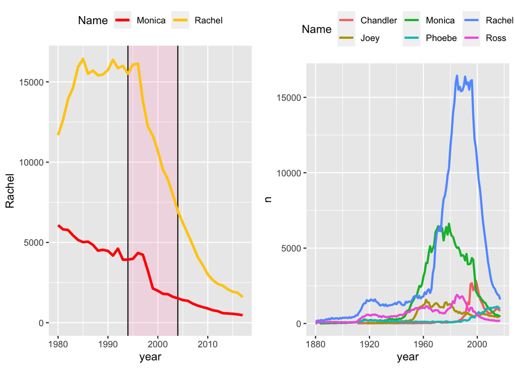

```r
friends_w = read.csv(file="~/Desktop/Rworkingdir/dataviz-main/data/friends_w.csv")
friends_l = read.csv(file="~/Desktop/Rworkingdir/dataviz-main/data/friends_l.csv")
g1=ggplot(data = friends_w)+
  #geom_rect(aes(xmin=1994,xmax=2004,ymin=-Inf,ymax=Inf),fill='lightblue',alpha=0.7)+
  annotate("rect", xmin=1994, xmax=2004,
                   ymin=-Inf, ymax=Inf,
           fill='#ff9abf',alpha=0.2) +
  geom_vline(xintercept = 1994) +
  geom_vline(xintercept = 2004) +
  geom_line(aes(year, y=Rachel,color='Rachel'), size=1.2) +
  geom_line(aes(year, y=Monica,    color='Monica'), size=1.2) +
  scale_color_manual(name='Name', values = c("#ff0000","#ffcb12"))+
  scale_x_continuous(limits = c(1980, 2017)) +
  theme(legend.position = "top")
g2=ggplot(data = friends_l, aes(year))+
  geom_line(aes(y=n,color=character_name),size=1)+
  scale_color_discrete("Name")+
  theme(legend.position = "top")
library(gridExtra)
grid.arrange(g1,g2,ncol=2)
```

### III. Area Plot A area plot is just the line plot but with the area below the line filled in with a certain color or texture. The area plot is drawn by first plotting data points on a Cartesian coordinate grid, joining a line between the points and finally filling in the space below the completed line.

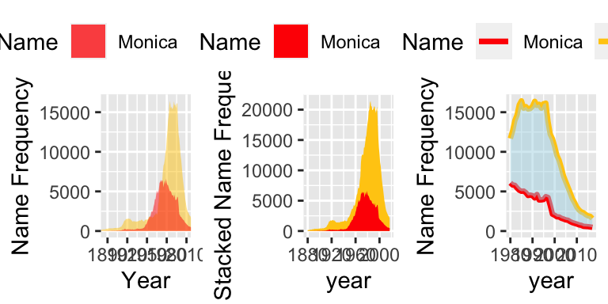

```r
library(readxl)
library(ggplot2)
library(reshape2)
friends_w = read.csv(file="~/Desktop/Rworkingdir/dataviz-main/data/friends_w.csv")
g1=ggplot(data = friends_w, aes(x=year)) +
  geom_area(aes(y=Rachel,fill="Rachel"),alpha=0.5)+
  geom_area(aes(y=Monica    ,fill="Monica"),alpha=0.5)+
  scale_fill_manual(name='Name',values = c("#ff0000","#ffcb12"))+
  scale_x_continuous(expand = c(0,0))+
  ylab('Name Frequency') + xlab('Year') +
  theme(legend.position = "top")
g2=ggplot(data = friends_w, aes(x=year))+
  geom_area(aes(y=Monica+Rachel ,fill="Rachel"))+
  geom_area(aes(y=Monica          ,fill="Monica"))+
  scale_fill_manual(name='Name',values = c("#ff0000","#ffcb12"))+
  ylab('Stacked Name Frequency') +
  theme(legend.position = "top")
g3=ggplot(friends_w)+
  geom_line(aes(year,y=Rachel,color='Rachel'),size=1.2)+
  geom_line(aes(year,y=Monica,    color='Monica'),size=1.2)+
  scale_color_manual(name='Name',values = c("#ff0000","#ffcb12"))+
  geom_ribbon(aes(x=year,ymin=Rachel,ymax=Monica),fill='lightblue',alpha=0.5)+
  scale_x_continuous(limits=c(1980,2017))+
  ylab("Name Frequency") +
  theme(legend.position = "top")
grid.arrange(g1,g2,g3,ncol=3)
```

Now we use the long format to visualize the frequencies of all six names from Friends

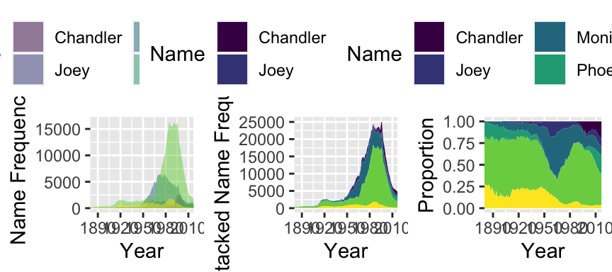

```r
friends_l = read.csv(file="~/Desktop/Rworkingdir/dataviz-main/data/friends_l.csv")
g1=ggplot(data = friends_l, aes(x=year)) +
  geom_area(aes(y=n, fill=character_name),
            position = "identity", alpha=0.5) +
  scale_x_continuous(expand = c(0,0))+
  scale_fill_viridis_d("Name")+
  ylab('Name Frequency') + xlab('Year')+
  theme(legend.position = "top")
g2=ggplot(data = friends_l, aes(x=year)) +
  geom_area(aes(y=n, fill=character_name),position="stack") +
  scale_x_continuous(expand = c(0,0))+
  scale_fill_viridis_d("Name")+
  ylab('Stacked Name Frequency') + xlab('Year')+
  theme(legend.position = "top")
g3=ggplot(data = friends_l, aes(x=year)) +
  geom_area(aes(y=n, fill=character_name),position="fill") +
  scale_x_continuous(expand = c(0,0))+
  scale_fill_viridis_d("Name")+
  ylab('Proportion') + xlab('Year')+
  theme(legend.position = "top")
grid.arrange(g1,g2,g3,ncol=3)
```

### IV.Stream Graph

Unlike a traditional stacked area graph in which the layers are stacked on top of an axis, in a stream graph the layers are positioned to minimize their “wiggle”. More formally, the layers are displaced to minimize the sum of the squared slopes of each layer, weighted by the area of the layer.

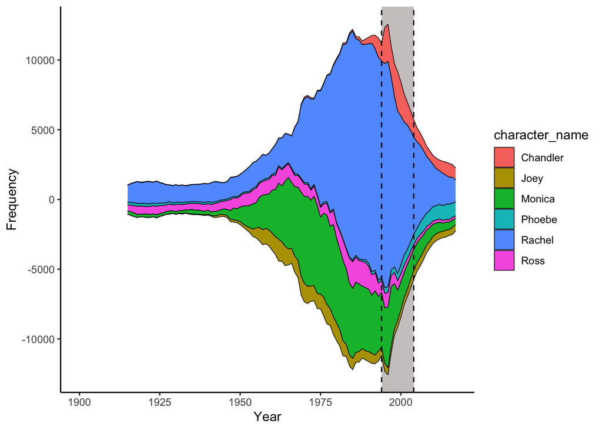

```r
devtools::install_github("hrbrmstr/streamgraph")
library(streamgraph)
library(ggTimeSeries)
friends_l =read.csv(file="~/Desktop/Rworkingdir/dataviz-main/data/friends_l.csv")
library(ggTimeSeries)
ggplot(friends_l) +
  geom_rect(aes(xmin=1994,xmax=2004,ymin=-Inf,ymax=Inf),fill='snow3')+
  stat_steamgraph(aes(x = year, y = n, group = character_name, fill = character_name),
                  color="black",size=0.25)+
  geom_vline(xintercept = 1994,linetype=2,size=0.5)+
  geom_vline(xintercept = 2004,linetype=2,size=0.5)+
  scale_x_continuous(limits = c(1900, 2017))+
  xlab('Year') +
  ylab('Frequency') +
  theme(panel.background = element_rect(fill='transparent'),
        axis.line.x = element_line(color = 'black'),
        axis.line.y = element_line(color = 'black'))
```

Interactive stream graph

```r
friends_l %>%
  group_by(year, character_name) %>%
  tally(wt=n) %>%
  streamgraph("character_name", "n", "year") %>%
  sg_legend(show = T, label = "Names")
```

[interactive chart not shown]

### V. Calendar-Based Scatter Plot

This type of plot is able to display the frequency of events in different time periods, for example, years, months, weeks and days. Calendar-based graphics is a variant of heat map, which can expand its application through linear transformation. Compared with heat maps, it can be used with other types of geom().

```r
if(!require(sugrrants)) install.packages("sugrrants")
library(sugrrants)
```

```r
CRWD <- read_csv("CRWD.csv")
```

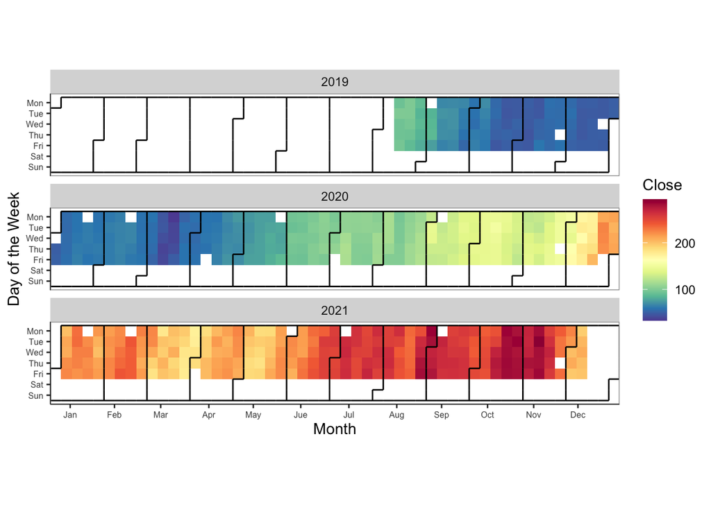

```r
library(RColorBrewer)
CRWD$date <- as.Date(CRWD$Date) ## transfer to date format
CRWD$year <- as.integer(strftime(CRWD$Date,'%Y'))  ## extract year
CRWD$month <- as.integer(strftime(CRWD$Date,'%m')) ## extract month
CRWD$week <- as.integer(strftime(CRWD$Date,'%W'))  ## extract week
month_locat <- c()
for(i in 1:12){
  month_locat[i] <- mean(CRWD$week[which(CRWD$month==i)])  ##find the average of every month
}

ggplot(data = CRWD, aes(date=Date,fill=Close))+
  stat_calendar_heatmap()+
  scale_fill_gradientn(colours= rev(brewer.pal(11,'Spectral')))+
  facet_wrap(~year,ncol = 1,strip.position = 'top')+  ## strip.position:'right','left','top'和'bottom'
  scale_y_continuous(breaks=seq(7,1,-1), labels=c("Mon","Tue","Wed","Thu","Fri","Sat","Sun")) +
  scale_x_continuous(breaks=month_locat,
                     labels=c("Jan","Feb","Mar","Apr","May","Jue",
                              "Jul","Aug","Sep","Oct","Nov","Dec"),
                     expand = c(0,0))+
  xlab("Month")+ylab("Day of the Week")+
  theme( panel.background = element_blank(),
         panel.border = element_rect(colour="grey60",fill=NA),  ## border for columns
         axis.line = element_line(colour="black",size=0.25),
         axis.text = element_text(size = 6))
```

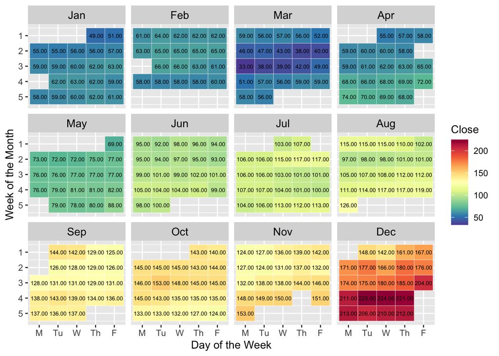

```r
# need to round Close value to 2 decimal so it can fit the calendar plot
CRWD$CRWD_2020_CLose_Round <- format(round(CRWD$Close), nsmall = 2)
CRWD_2020 <- CRWD[CRWD$year==2020,]
CRWD_2020$mon_fac <- factor(CRWD_2020$month,levels = as.character(1:12),
                          labels=c("Jan","Feb","Mar","Apr","May","Jun",
                                   "Jul","Aug","Sep","Oct","Nov","Dec"),ordered=TRUE)
CRWD_2020$weekday <- as.integer(strftime(CRWD_2020$date,'%u'))
CRWD_2020$wd_fac <- factor(CRWD_2020$weekday,levels = (1:7),labels=(c("M","Tu","W","Th","F","Sa","S")),ordered=TRUE)
CRWD_2020 <- CRWD_2020 %>% group_by(mon_fac) %>% mutate(monthweek= 1+week-min(week)) ## add new variable
ggplot(CRWD_2020,aes(wd_fac,monthweek,fill=Close))+
  geom_tile(color='white')+    ## white background
  scale_fill_gradientn(colours=rev(brewer.pal(11,'Spectral')))+
  facet_wrap(~mon_fac,nrow=3)+
  scale_y_reverse()+
    geom_text(aes(label=CRWD_2020_CLose_Round),size=2)+
  xlab('Day of the Week')+
  ylab('Week of the Month')+
  theme(strip.text = element_text(size=11,face="plain",color="black"))
```

### V.Spiral Plot

Spiral plot is also known as a time series spiral. This type of visualization plots time-based data along an Archimedean spiral. The graph begins at the centre of a spiral and then progresses outwards. Spiral Plots are versatile and can use bars, lines or points to be displayed along the spiral path. Spiral plots are ideal for showing large data sets, usually to show trends over a large time period. This makes spiral Plots great for displaying periodic patterns. Color can be assigned to each period to break them up and to allow some comparison between each period.

##### Spiral histogram

The data set is the average wind speed(m/s) from 06/11/2019 0:00 to 06/16/2019 21:30 in Adigala, Ethiopia. The data are collected every 10 mintues.

```r
library(lubridate)
wind <- read.csv("wind speed.csv")
wind$time <- ymd_hm(wind$time)   ## transfer to POSIXct type
wind$hour <- hour(wind$time) + minute(wind$time)/60  ## in hour
wind$day <- as.Date(wind$time)  ## everyday
spiral_his <- wind %>%
          mutate(hour_group = cut(wind$hour,breaks = seq(0,24,0.5),  ## transfer to every 30 mintues
                                   labels = seq(0,23.5,0.5),include.lowest = T),
                  hour_group = as.numeric(as.character(hour_group)))  %>%
          group_by(day,hour_group) %>%  ## group by the cycle time( day )
          summarise(meanS =mean(wind_speed))  %>% ##  the average of group
          mutate(localtime = as.POSIXct(day) + hour_group*3600)  ##  hour to second
spiral_his
```

```
## # A tibble: 283 × 4
## # Groups:   day [6]
##    day        hour_group meanS localtime
##    <date>          <dbl> <dbl> <dttm>
##  1 2019-06-11        0   1.99  2019-06-10 20:00:00
##  2 2019-06-11        0.5 2.19  2019-06-10 20:30:00
##  3 2019-06-11        1   1.15  2019-06-10 21:00:00
##  4 2019-06-11        1.5 0.693 2019-06-10 21:30:00
##  5 2019-06-11        2   0.772 2019-06-10 22:00:00
##  6 2019-06-11        2.5 0.825 2019-06-10 22:30:00
##  7 2019-06-11        3   0.867 2019-06-10 23:00:00
##  8 2019-06-11        3.5 0.467 2019-06-10 23:30:00
##  9 2019-06-11        4   0.869 2019-06-11 00:00:00
## 10 2019-06-11        4.5 1.73  2019-06-11 00:30:00
## # … with 273 more rows
```

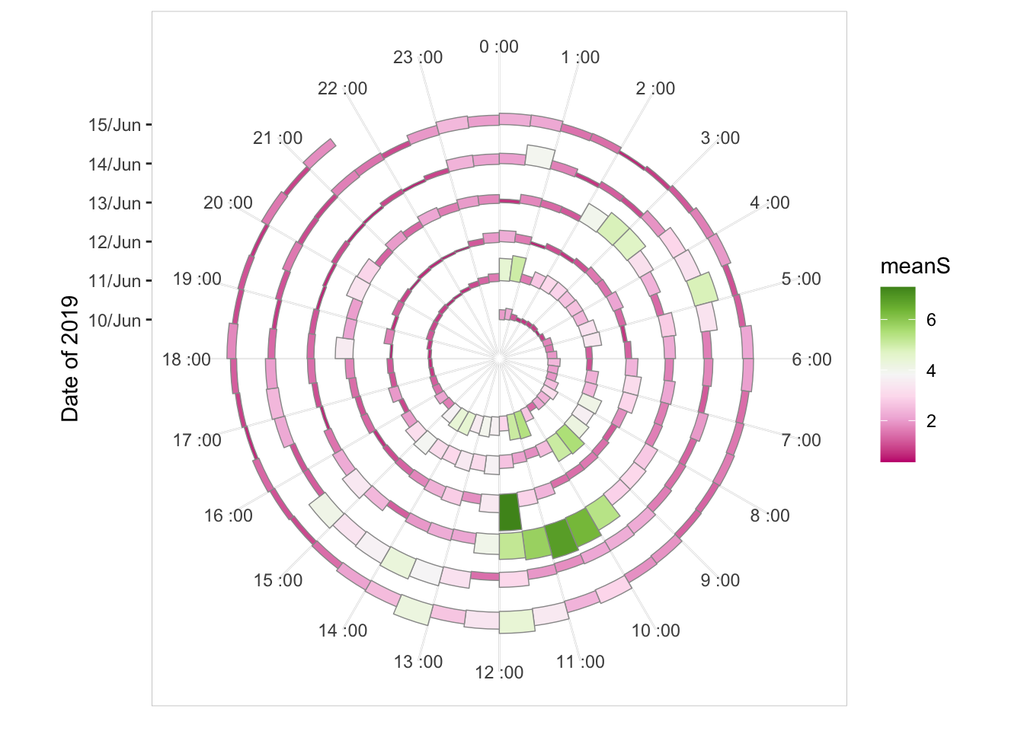

```r
ggplot(spiral_his)+
  geom_rect(aes(xmin=hour_group,xmax=hour_group+0.5,
                ymin=localtime,ymax=localtime+meanS*11111,  ## 11111 is the multiplier
                fill=meanS),color='gray60',size=0.25)+
  scale_fill_gradientn(colors = colorRampPalette(brewer.pal(9,'PiYG'))(9))+
  scale_y_datetime(limits = range(spiral_his$localtime)+c(-24*3600,6*3600),  ## adjust the position of the cycle
                   breaks = seq(min(spiral_his$localtime),max(spiral_his$localtime),'1 day'),#cycle time( day )
                   date_labels ='%e/%b')+
  scale_x_continuous(limits = c(0,24),breaks = 0:23,   ## break time as 0-24
                     minor_breaks = 0:24,labels = paste(0:23,':00'))+
  ylab('Date of 2019')+
  coord_polar()+
  theme( panel.background = element_blank(),  ## delete the background
         panel.border =  element_rect(fill=NA,colour = "grey",size=.25), # add bord
         panel.grid.major.y  = element_blank(),    # add cycles
         panel.grid.major.x  = element_line(colour = "grey",size=0.35),)  # add label line
```

##### Concentric circle

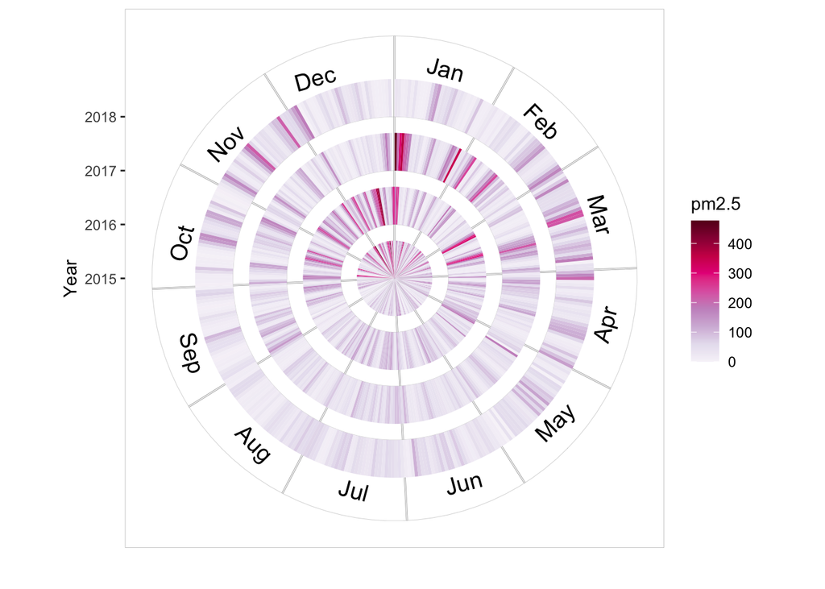

```r
pm25_raw <- read.csv("pm25.csv")
pm25 <- pm25_raw[,c(1,3)]
pm25$date <- ymd(pm25$date)
## Cycle time--year
pm25$year <- year(pm25$date)
## which day in the
pm25$day <- yday(pm25$date)
pm25_df <- pm25 %>% group_by(day,year)
ggplot() +
  geom_rect(data=pm25_df,aes(xmin=day,xmax=day+1,
                ymin=year,ymax=year+0.7,fill=pm2.5))+
  scale_fill_gradientn(colors = colorRampPalette(brewer.pal(9,'PuRd'))(9))+
  scale_x_continuous(breaks=c(1,31,59,90,120,151,181,212,243,273,304,334),
                     labels = c())+
  scale_y_continuous(breaks = c(2015,2016,2017,2018),labels = c(2015,2016,2017,2018))+
  geom_text(data=NULL,aes(x=seq(15,345,length=12),
                          y=rep(2019,length=12),
                        label=c("Jan","Feb","Mar","Apr","May","Jun","Jul","Aug","Sep","Oct","Nov","Dec"),
                        angle=rep(c(-seq(15,345,length=12)[1:3],rev(seq(15,345,length=12)[1:3])),2)),
            size=5,color="black")+
  ylab('Year')+
  xlab('')+
  coord_polar()+
  theme(panel.background = element_blank(),
        panel.border =  element_rect(fill=NA,colour = "grey",size=.25),
        panel.grid.major.y  = element_line(colour = "grey",size=0.1),
        panel.grid.major.x  = element_line(colour = "grey60",size=0.5))
```